# Optimal Treatment Analysis

## Outcome Variable

**Outcome Variable:** ever_stunted

## Predictor Variables

**Intervention Variable:** nchldlt5

**Adjustment Set:**

- arm
- W_mage
- meducyrs
- feducyrs
- hhwealth_quart
- hfoodsec
- W_mhtcm
- W_nrooms
- W_parity
- impfloor
- impsan
- safeh20
- delta_W_mage
- delta_meducyrs
- delta_feducyrs
- delta_hhwealth_quart
- delta_hfoodsec
- delta_W_mhtcm
- delta_W_nrooms
- delta_W_parity
- delta_impfloor
- delta_impsan
- delta_safeh20

## Stratifying Variables

The analysis was stratified on these variable(s):

- agecat
- studyid
- country

## Data Summary

| agecat | studyid | country | nchldlt5 | ever_stunted | n_cell | n |
| --- | --- | --- | --- | --- | --- | --- |
| 0-24 months | ki1000108-IRC | INDIA | 1 | 0 | 35 | 291 |
| 0-24 months | ki1000108-IRC | INDIA | 1 | 1 | 54 | 291 |
| 0-24 months | ki1000108-IRC | INDIA | 2+ | 0 | 70 | 291 |
| 0-24 months | ki1000108-IRC | INDIA | 2+ | 1 | 132 | 291 |
| 0-24 months | ki1017093b-PROVIDE | BANGLADESH | 1 | 0 | 295 | 524 |
| 0-24 months | ki1017093b-PROVIDE | BANGLADESH | 1 | 1 | 217 | 524 |
| 0-24 months | ki1017093b-PROVIDE | BANGLADESH | 2+ | 0 | 9 | 524 |
| 0-24 months | ki1017093b-PROVIDE | BANGLADESH | 2+ | 1 | 3 | 524 |
| 0-24 months | ki1017093c-NIH-Crypto | BANGLADESH | 1 | 0 | 298 | 547 |
| 0-24 months | ki1017093c-NIH-Crypto | BANGLADESH | 1 | 1 | 243 | 547 |
| 0-24 months | ki1017093c-NIH-Crypto | BANGLADESH | 2+ | 0 | 4 | 547 |
| 0-24 months | ki1017093c-NIH-Crypto | BANGLADESH | 2+ | 1 | 2 | 547 |
| 0-24 months | ki1066203-TanzaniaChild2 | TANZANIA, UNITED REPUBLIC OF | 1 | 0 | 1077 | 1716 |
| 0-24 months | ki1066203-TanzaniaChild2 | TANZANIA, UNITED REPUBLIC OF | 1 | 1 | 560 | 1716 |
| 0-24 months | ki1066203-TanzaniaChild2 | TANZANIA, UNITED REPUBLIC OF | 2+ | 0 | 51 | 1716 |
| 0-24 months | ki1066203-TanzaniaChild2 | TANZANIA, UNITED REPUBLIC OF | 2+ | 1 | 28 | 1716 |
| 0-24 months | ki1112895-iLiNS-Zinc | BURKINA FASO | 1 | 0 | 711 | 1916 |
| 0-24 months | ki1112895-iLiNS-Zinc | BURKINA FASO | 1 | 1 | 362 | 1916 |
| 0-24 months | ki1112895-iLiNS-Zinc | BURKINA FASO | 2+ | 0 | 496 | 1916 |
| 0-24 months | ki1112895-iLiNS-Zinc | BURKINA FASO | 2+ | 1 | 347 | 1916 |
| 0-24 months | ki1148112-LCNI-5 | MALAWI | 1 | 0 | 145 | 454 |
| 0-24 months | ki1148112-LCNI-5 | MALAWI | 1 | 1 | 246 | 454 |
| 0-24 months | ki1148112-LCNI-5 | MALAWI | 2+ | 0 | 24 | 454 |
| 0-24 months | ki1148112-LCNI-5 | MALAWI | 2+ | 1 | 39 | 454 |
| 0-24 months | kiGH5241-JiVitA-3 | BANGLADESH | 1 | 0 | 17101 | 36063 |
| 0-24 months | kiGH5241-JiVitA-3 | BANGLADESH | 1 | 1 | 17683 | 36063 |
| 0-24 months | kiGH5241-JiVitA-3 | BANGLADESH | 2+ | 0 | 695 | 36063 |
| 0-24 months | kiGH5241-JiVitA-3 | BANGLADESH | 2+ | 1 | 584 | 36063 |
| 0-6 months | ki1000108-IRC | INDIA | 1 | 0 | 49 | 291 |
| 0-6 months | ki1000108-IRC | INDIA | 1 | 1 | 40 | 291 |
| 0-6 months | ki1000108-IRC | INDIA | 2+ | 0 | 118 | 291 |
| 0-6 months | ki1000108-IRC | INDIA | 2+ | 1 | 84 | 291 |
| 0-6 months | ki1017093b-PROVIDE | BANGLADESH | 1 | 0 | 384 | 524 |
| 0-6 months | ki1017093b-PROVIDE | BANGLADESH | 1 | 1 | 128 | 524 |
| 0-6 months | ki1017093b-PROVIDE | BANGLADESH | 2+ | 0 | 10 | 524 |
| 0-6 months | ki1017093b-PROVIDE | BANGLADESH | 2+ | 1 | 2 | 524 |
| 0-6 months | ki1017093c-NIH-Crypto | BANGLADESH | 1 | 0 | 386 | 547 |
| 0-6 months | ki1017093c-NIH-Crypto | BANGLADESH | 1 | 1 | 155 | 547 |
| 0-6 months | ki1017093c-NIH-Crypto | BANGLADESH | 2+ | 0 | 6 | 547 |
| 0-6 months | ki1017093c-NIH-Crypto | BANGLADESH | 2+ | 1 | 0 | 547 |
| 0-6 months | ki1066203-TanzaniaChild2 | TANZANIA, UNITED REPUBLIC OF | 1 | 0 | 1311 | 1716 |
| 0-6 months | ki1066203-TanzaniaChild2 | TANZANIA, UNITED REPUBLIC OF | 1 | 1 | 326 | 1716 |
| 0-6 months | ki1066203-TanzaniaChild2 | TANZANIA, UNITED REPUBLIC OF | 2+ | 0 | 66 | 1716 |
| 0-6 months | ki1066203-TanzaniaChild2 | TANZANIA, UNITED REPUBLIC OF | 2+ | 1 | 13 | 1716 |
| 0-6 months | ki1148112-LCNI-5 | MALAWI | 1 | 0 | 81 | 145 |
| 0-6 months | ki1148112-LCNI-5 | MALAWI | 1 | 1 | 41 | 145 |
| 0-6 months | ki1148112-LCNI-5 | MALAWI | 2+ | 0 | 13 | 145 |
| 0-6 months | ki1148112-LCNI-5 | MALAWI | 2+ | 1 | 10 | 145 |
| 0-6 months | kiGH5241-JiVitA-3 | BANGLADESH | 1 | 0 | 19644 | 36004 |
| 0-6 months | kiGH5241-JiVitA-3 | BANGLADESH | 1 | 1 | 15082 | 36004 |
| 0-6 months | kiGH5241-JiVitA-3 | BANGLADESH | 2+ | 0 | 826 | 36004 |
| 0-6 months | kiGH5241-JiVitA-3 | BANGLADESH | 2+ | 1 | 452 | 36004 |
| 6-24 months | ki1000108-IRC | INDIA | 1 | 0 | 35 | 167 |
| 6-24 months | ki1000108-IRC | INDIA | 1 | 1 | 14 | 167 |
| 6-24 months | ki1000108-IRC | INDIA | 2+ | 0 | 70 | 167 |
| 6-24 months | ki1000108-IRC | INDIA | 2+ | 1 | 48 | 167 |
| 6-24 months | ki1017093b-PROVIDE | BANGLADESH | 1 | 0 | 238 | 335 |
| 6-24 months | ki1017093b-PROVIDE | BANGLADESH | 1 | 1 | 89 | 335 |
| 6-24 months | ki1017093b-PROVIDE | BANGLADESH | 2+ | 0 | 7 | 335 |
| 6-24 months | ki1017093b-PROVIDE | BANGLADESH | 2+ | 1 | 1 | 335 |
| 6-24 months | ki1017093c-NIH-Crypto | BANGLADESH | 1 | 0 | 280 | 373 |
| 6-24 months | ki1017093c-NIH-Crypto | BANGLADESH | 1 | 1 | 88 | 373 |
| 6-24 months | ki1017093c-NIH-Crypto | BANGLADESH | 2+ | 0 | 3 | 373 |
| 6-24 months | ki1017093c-NIH-Crypto | BANGLADESH | 2+ | 1 | 2 | 373 |
| 6-24 months | ki1066203-TanzaniaChild2 | TANZANIA, UNITED REPUBLIC OF | 1 | 0 | 858 | 1145 |
| 6-24 months | ki1066203-TanzaniaChild2 | TANZANIA, UNITED REPUBLIC OF | 1 | 1 | 234 | 1145 |
| 6-24 months | ki1066203-TanzaniaChild2 | TANZANIA, UNITED REPUBLIC OF | 2+ | 0 | 38 | 1145 |
| 6-24 months | ki1066203-TanzaniaChild2 | TANZANIA, UNITED REPUBLIC OF | 2+ | 1 | 15 | 1145 |
| 6-24 months | ki1112895-iLiNS-Zinc | BURKINA FASO | 1 | 0 | 711 | 1916 |
| 6-24 months | ki1112895-iLiNS-Zinc | BURKINA FASO | 1 | 1 | 362 | 1916 |
| 6-24 months | ki1112895-iLiNS-Zinc | BURKINA FASO | 2+ | 0 | 496 | 1916 |
| 6-24 months | ki1112895-iLiNS-Zinc | BURKINA FASO | 2+ | 1 | 347 | 1916 |
| 6-24 months | ki1148112-LCNI-5 | MALAWI | 1 | 0 | 138 | 395 |
| 6-24 months | ki1148112-LCNI-5 | MALAWI | 1 | 1 | 205 | 395 |
| 6-24 months | ki1148112-LCNI-5 | MALAWI | 2+ | 0 | 23 | 395 |
| 6-24 months | ki1148112-LCNI-5 | MALAWI | 2+ | 1 | 29 | 395 |
| 6-24 months | kiGH5241-JiVitA-3 | BANGLADESH | 1 | 0 | 10465 | 13563 |
| 6-24 months | kiGH5241-JiVitA-3 | BANGLADESH | 1 | 1 | 2601 | 13563 |
| 6-24 months | kiGH5241-JiVitA-3 | BANGLADESH | 2+ | 0 | 365 | 13563 |
| 6-24 months | kiGH5241-JiVitA-3 | BANGLADESH | 2+ | 1 | 132 | 13563 |

The following strata were considered:

- agecat: 0-24 months, studyid: ki1000108-IRC, country: INDIA
- agecat: 0-24 months, studyid: ki1017093b-PROVIDE, country: BANGLADESH
- agecat: 0-24 months, studyid: ki1017093c-NIH-Crypto, country: BANGLADESH
- agecat: 0-24 months, studyid: ki1066203-TanzaniaChild2, country: TANZANIA, UNITED REPUBLIC OF
- agecat: 0-24 months, studyid: ki1112895-iLiNS-Zinc, country: BURKINA FASO
- agecat: 0-24 months, studyid: ki1148112-LCNI-5, country: MALAWI
- agecat: 0-24 months, studyid: kiGH5241-JiVitA-3, country: BANGLADESH
- agecat: 0-6 months, studyid: ki1000108-IRC, country: INDIA
- agecat: 0-6 months, studyid: ki1017093b-PROVIDE, country: BANGLADESH
- agecat: 0-6 months, studyid: ki1017093c-NIH-Crypto, country: BANGLADESH
- agecat: 0-6 months, studyid: ki1066203-TanzaniaChild2, country: TANZANIA, UNITED REPUBLIC OF
- agecat: 0-6 months, studyid: ki1148112-LCNI-5, country: MALAWI
- agecat: 0-6 months, studyid: kiGH5241-JiVitA-3, country: BANGLADESH
- agecat: 6-24 months, studyid: ki1000108-IRC, country: INDIA
- agecat: 6-24 months, studyid: ki1017093b-PROVIDE, country: BANGLADESH
- agecat: 6-24 months, studyid: ki1017093c-NIH-Crypto, country: BANGLADESH
- agecat: 6-24 months, studyid: ki1066203-TanzaniaChild2, country: TANZANIA, UNITED REPUBLIC OF
- agecat: 6-24 months, studyid: ki1112895-iLiNS-Zinc, country: BURKINA FASO
- agecat: 6-24 months, studyid: ki1148112-LCNI-5, country: MALAWI
- agecat: 6-24 months, studyid: kiGH5241-JiVitA-3, country: BANGLADESH

### Dropped Strata

Some strata were dropped due to rare outcomes:

- agecat: 0-24 months, studyid: ki1017093b-PROVIDE, country: BANGLADESH
- agecat: 0-24 months, studyid: ki1017093c-NIH-Crypto, country: BANGLADESH
- agecat: 0-6 months, studyid: ki1017093b-PROVIDE, country: BANGLADESH
- agecat: 0-6 months, studyid: ki1017093c-NIH-Crypto, country: BANGLADESH
- agecat: 6-24 months, studyid: ki1017093b-PROVIDE, country: BANGLADESH
- agecat: 6-24 months, studyid: ki1017093c-NIH-Crypto, country: BANGLADESH

## Methods Detail

We’re interested in the causal parameters $E[Y_a]$ for all values of $a \in \mathcal{A}$. These parameters represent the mean outcome if, possibly contrary to fact, we intervened to set all units to have $A=a$. Under the randomization and positivity assumptions, these are identified by the statistical parameters $\psi_a=E_W[E_{Y|A,W}(Y|A=a,W)]$. In addition, we’re interested in the mean of $Y$, $E[Y]$ under no intervention (the observed mean). We will estimate these parameters by using SuperLearner to fit the relevant likelihood factors – $E_{Y|A,W}(Y|A=a,W)$ and $p(A=a|W)$, and then updating our likelihood fit using a joint TMLE.

For unadjusted analyses ($W=\{\}$), initial likelihoods were estimated using Lrnr_glm to estimate the simple $E(Y|A)$ and Lrnr_mean to estimate $p(A)$. For adjusted analyses, a small library containing Lrnr_glmnet, Lrnr_xgboost, and Lrnr_mean was used.

Having estimated these parameters, we will then use the delta method to estimate relative risks and attributable risks relative to a prespecified baseline level of $A$.

# Results Detail

## Results Plots

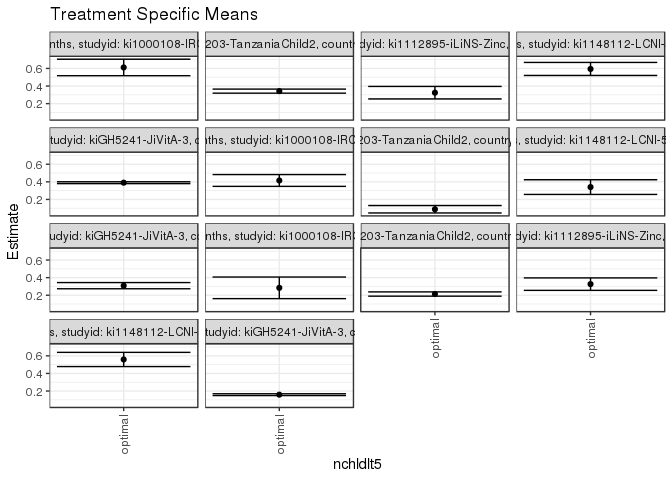

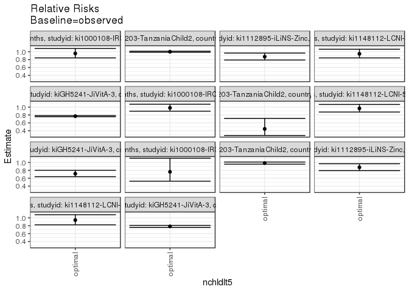

## Results Table

### Parameter: TSM

| agecat | studyid | country | intervention_level | baseline_level | estimate | ci_lower | ci_upper |
| --- | --- | --- | --- | --- | --- | --- | --- |
| 0-24 months | ki1000108-IRC | INDIA | optimal | NA | 0.6114252 | 0.5177710 | 0.7050795 |
| 0-24 months | ki1066203-TanzaniaChild2 | TANZANIA, UNITED REPUBLIC OF | optimal | NA | 0.3421377 | 0.3191824 | 0.3650930 |
| 0-24 months | ki1112895-iLiNS-Zinc | BURKINA FASO | optimal | NA | 0.3244823 | 0.2535510 | 0.3954136 |
| 0-24 months | ki1148112-LCNI-5 | MALAWI | optimal | NA | 0.5942399 | 0.5203310 | 0.6681489 |
| 0-24 months | kiGH5241-JiVitA-3 | BANGLADESH | optimal | NA | 0.3903340 | 0.3798995 | 0.4007686 |
| 0-6 months | ki1000108-IRC | INDIA | optimal | NA | 0.4154604 | 0.3485237 | 0.4823971 |
| 0-6 months | ki1066203-TanzaniaChild2 | TANZANIA, UNITED REPUBLIC OF | optimal | NA | 0.0883084 | 0.0460082 | 0.1306085 |
| 0-6 months | ki1148112-LCNI-5 | MALAWI | optimal | NA | 0.3402887 | 0.2567003 | 0.4238771 |
| 0-6 months | kiGH5241-JiVitA-3 | BANGLADESH | optimal | NA | 0.3087112 | 0.2734820 | 0.3439404 |
| 6-24 months | ki1000108-IRC | INDIA | optimal | NA | 0.2840403 | 0.1613043 | 0.4067764 |
| 6-24 months | ki1066203-TanzaniaChild2 | TANZANIA, UNITED REPUBLIC OF | optimal | NA | 0.2136389 | 0.1893102 | 0.2379676 |
| 6-24 months | ki1112895-iLiNS-Zinc | BURKINA FASO | optimal | NA | 0.3262389 | 0.2553385 | 0.3971392 |
| 6-24 months | ki1148112-LCNI-5 | MALAWI | optimal | NA | 0.5585927 | 0.4779984 | 0.6391870 |
| 6-24 months | kiGH5241-JiVitA-3 | BANGLADESH | optimal | NA | 0.1583899 | 0.1481590 | 0.1686207 |

### Parameter: E(Y)

| agecat | studyid | country | intervention_level | baseline_level | estimate | ci_lower | ci_upper |
| --- | --- | --- | --- | --- | --- | --- | --- |
| 0-24 months | ki1000108-IRC | INDIA | observed | NA | 0.6399400 | 0.5846678 | 0.6952123 |
| 0-24 months | ki1066203-TanzaniaChild2 | TANZANIA, UNITED REPUBLIC OF | observed | NA | 0.3424240 | 0.3199623 | 0.3648857 |
| 0-24 months | ki1112895-iLiNS-Zinc | BURKINA FASO | observed | NA | 0.3716796 | 0.3196561 | 0.4237031 |
| 0-24 months | ki1148112-LCNI-5 | MALAWI | observed | NA | 0.6279104 | 0.5833951 | 0.6724256 |
| 0-24 months | kiGH5241-JiVitA-3 | BANGLADESH | observed | NA | 0.5072187 | 0.4979096 | 0.5165277 |
| 0-6 months | ki1000108-IRC | INDIA | observed | NA | 0.4236442 | 0.3667295 | 0.4805590 |
| 0-6 months | ki1066203-TanzaniaChild2 | TANZANIA, UNITED REPUBLIC OF | observed | NA | 0.1976753 | 0.1788317 | 0.2165190 |
| 0-6 months | ki1148112-LCNI-5 | MALAWI | observed | NA | 0.3519413 | 0.2739497 | 0.4299329 |
| 0-6 months | kiGH5241-JiVitA-3 | BANGLADESH | observed | NA | 0.4315682 | 0.4225472 | 0.4405892 |
| 6-24 months | ki1000108-IRC | INDIA | observed | NA | 0.3723292 | 0.2988325 | 0.4458259 |
| 6-24 months | ki1066203-TanzaniaChild2 | TANZANIA, UNITED REPUBLIC OF | observed | NA | 0.2170616 | 0.1931569 | 0.2409663 |
| 6-24 months | ki1112895-iLiNS-Zinc | BURKINA FASO | observed | NA | 0.3723585 | 0.3203350 | 0.4243819 |
| 6-24 months | ki1148112-LCNI-5 | MALAWI | observed | NA | 0.5923488 | 0.5438285 | 0.6408692 |
| 6-24 months | kiGH5241-JiVitA-3 | BANGLADESH | observed | NA | 0.2022545 | 0.1909755 | 0.2135335 |

### Parameter: RR

| agecat | studyid | country | intervention_level | baseline_level | estimate | ci_lower | ci_upper |
| --- | --- | --- | --- | --- | --- | --- | --- |
| 0-24 months | ki1000108-IRC | INDIA | optimal | observed | 0.9554415 | 0.8426731 | 1.0833008 |
| 0-24 months | ki1066203-TanzaniaChild2 | TANZANIA, UNITED REPUBLIC OF | optimal | observed | 0.9991640 | 0.9850607 | 1.0134692 |
| 0-24 months | ki1112895-iLiNS-Zinc | BURKINA FASO | optimal | observed | 0.8730162 | 0.7897271 | 0.9650895 |
| 0-24 months | ki1148112-LCNI-5 | MALAWI | optimal | observed | 0.9463770 | 0.8424677 | 1.0631023 |
| 0-24 months | kiGH5241-JiVitA-3 | BANGLADESH | optimal | observed | 0.7695577 | 0.7554932 | 0.7838841 |
| 0-6 months | ki1000108-IRC | INDIA | optimal | observed | 0.9806823 | 0.8966739 | 1.0725613 |
| 0-6 months | ki1066203-TanzaniaChild2 | TANZANIA, UNITED REPUBLIC OF | optimal | observed | 0.4467343 | 0.2796769 | 0.7135790 |
| 0-6 months | ki1148112-LCNI-5 | MALAWI | optimal | observed | 0.9668904 | 0.8749300 | 1.0685163 |
| 0-6 months | kiGH5241-JiVitA-3 | BANGLADESH | optimal | observed | 0.7153242 | 0.6389271 | 0.8008562 |
| 6-24 months | ki1000108-IRC | INDIA | optimal | observed | 0.7628742 | 0.5250394 | 1.1084444 |
| 6-24 months | ki1066203-TanzaniaChild2 | TANZANIA, UNITED REPUBLIC OF | optimal | observed | 0.9842318 | 0.9582526 | 1.0109152 |
| 6-24 months | ki1112895-iLiNS-Zinc | BURKINA FASO | optimal | observed | 0.8761419 | 0.7933350 | 0.9675921 |
| 6-24 months | ki1148112-LCNI-5 | MALAWI | optimal | observed | 0.9430130 | 0.8234031 | 1.0799979 |
| 6-24 months | kiGH5241-JiVitA-3 | BANGLADESH | optimal | observed | 0.7831215 | 0.7582316 | 0.8088285 |